# Data Preprocessing

**Last Updated Atrribute**

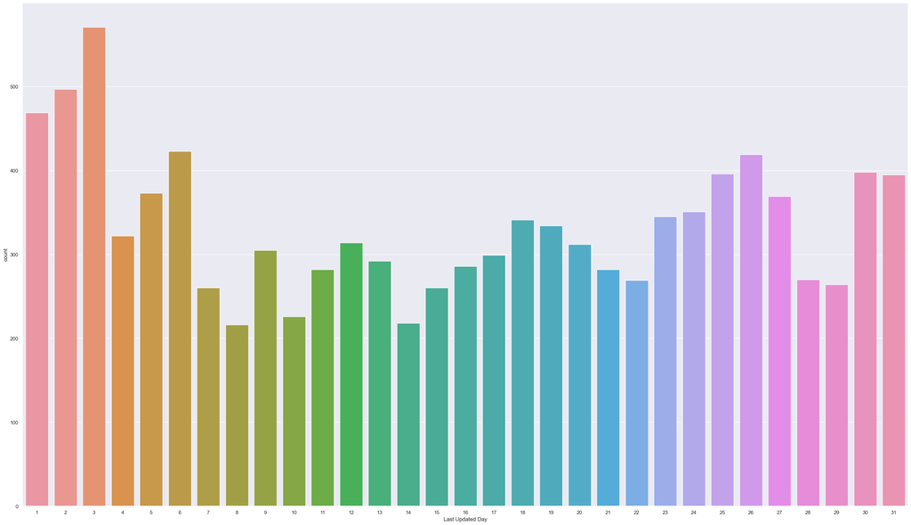

```python
sns.countplot(data=new_data,x='Last Updated Day')
# new_data['Last Updated Day'].value_counts()
```

The distribution of last updated days for apps reveals several insights:

1. **Recent Updates**: Days like 3, 2, 1, and 6 show a high frequency of updates, indicating that developers are actively releasing new versions or updates for their apps.
2. **Consistent Updates**: Days like 26, 30, 25, and 31 also have a considerable number of updates, suggesting that app developers maintain a consistent schedule for releasing updates, possibly to fix bugs or add new features.
3. **Mid-Month Updates**: Days like 15, 16, and 17 have a moderate number of updates, indicating that app updates are distributed throughout the month rather than clustered around specific dates.
4. **Less Frequent Updates**: Days like 10, 14, and 8 have fewer updates compared to other days, suggesting that fewer app developers choose these days for releasing updates, possibly due to strategic considerations or lower activity periods.
5. **Weekend Updates**: It's interesting to note that updates are spread across the entire month, including weekends (e.g., days 7 and 8), indicating that app developers may not necessarily avoid weekends for releasing updates.

Overall, this distribution highlights the dynamic nature of app updates, with developers regularly pushing updates to keep their apps relevant and functional.

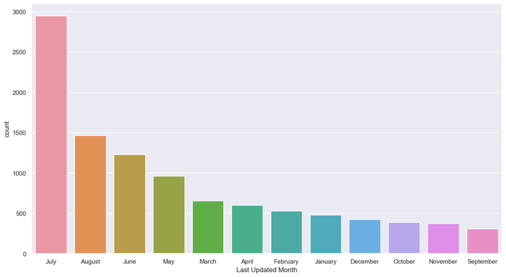

```python
plt.figure(figsize=(15,8))
sns.countplot(data=new_data,x='Last Updated Month',order=new_data['Last Updated Month'].value_counts().index)
```

The distribution of last updated months for apps provides the following insights:

1. **Recent Updates**: July shows the highest frequency of updates, indicating that it's a popular month for app developers to release new versions or updates.
2. **Summer Updates**: Months like July, August, and June have relatively higher frequencies compared to other months, suggesting that app updates are more common during the summer months, possibly coinciding with increased user activity and engagement.
3. **Beginning of the Year**: Months like January and February have moderate frequencies, indicating that app updates are also common at the beginning of the year, possibly as developers start the year with new features or improvements.
4. **Year-end Updates**: December has a relatively lower frequency compared to other months, indicating that app updates may be less frequent towards the end of the year, possibly due to holidays or year-end planning.
5. **Steady Updates**: Months like May, March, and April have moderate frequencies, indicating a steady flow of app updates throughout the year.

Overall, this distribution suggests that app updates are distributed across the year, with certain months experiencing higher activity levels than others, likely influenced by factors such as seasonal trends, user engagement patterns, and developer strategies.

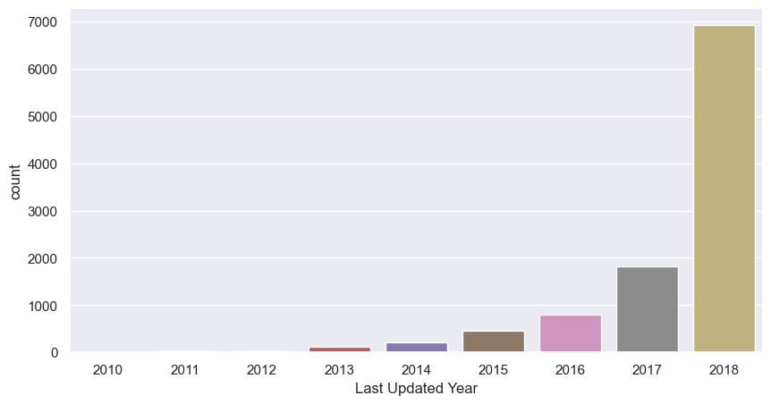

```python
plt.figure(figsize=(10,5))
sns.countplot(data=new_data,x='Last Updated Year')
```

Overall, this distribution underscores the dynamic nature of app development, with a focus on ongoing maintenance and updates to provide users with optimal experiences while also reflecting the lifecycle of apps over time.

# Dropping Columns

```python
new_data.info()
```

```
<class 'pandas.core.frame.DataFrame'>
Index: 10358 entries, 0 to 10840
Data columns (total 22 columns):
 #   Column                Non-Null Count  Dtype
---  ------                --------------  -----
 0   App                   10358 non-null  object
 1   Category              10358 non-null  object
 2   Rating                10358 non-null  float64
 3   Reviews               10358 non-null  int32
 4   Size                  10358 non-null  float64
 5   Installs              10358 non-null  int32
 6   Type                  10358 non-null  object
 7   Price                 10358 non-null  float64
 8   Content Rating        10358 non-null  object
 9   Genres                10358 non-null  object
 10  Last Updated          10358 non-null  datetime64[ns]
 11  Current Ver           10358 non-null  object
 12  Android Ver           10358 non-null  object
 13  Reviews Category      9765 non-null   category
 14  Size Category         10358 non-null  category
 15  Installs Categorical  10358 non-null  category
 16  Price Category        10358 non-null  category
 17  Rating Category       10358 non-null  category
 18  Last Updated Day      10358 non-null  int32
 19  Last Updated Month    10358 non-null  object
 20  Last Updated Year     10358 non-null  int32
 21  Minimum Android Ver   10358 non-null  object
dtypes: category(5), datetime64[ns](1), float64(3), int32(4), object(9)
memory usage: 1.6+ MB
```

```python
new_data.drop(columns=['App','Current Ver', 'Android Ver', 'Last Updated'], axis=1,inplace=True)
```

```python
new_data.drop(columns=['Genres'],axis=1, inplace=True)
```

```python
new_data.info()
```

```
<class 'pandas.core.frame.DataFrame'>
Index: 10358 entries, 0 to 10840
Data columns (total 17 columns):
 #   Column                Non-Null Count  Dtype
---  ------                --------------  -----
 0   Category              10358 non-null  object
 1   Rating                10358 non-null  float64
 2   Reviews               10358 non-null  int32
 3   Size                  10358 non-null  float64
 4   Installs              10358 non-null  int32
 5   Type                  10358 non-null  object
 6   Price                 10358 non-null  float64
 7   Content Rating        10358 non-null  object
 8   Reviews Category      9765 non-null   category
 9   Size Category         10358 non-null  category
 10  Installs Categorical  10358 non-null  category
 11  Price Category        10358 non-null  category
 12  Rating Category       10358 non-null  category
 13  Last Updated Day      10358 non-null  int32
 14  Last Updated Month    10358 non-null  object
 15  Last Updated Year     10358 non-null  int32
 16  Minimum Android Ver   10358 non-null  object
dtypes: category(5), float64(3), int32(4), object(5)
memory usage: 1.2+ MB
```

```python
new_data.tail()
```

|  | Category | Rating | Reviews | Size | Installs | Type | Price | Content Rating | Reviews Category | Size Category | Installs Categorical | Price Category | Rating Category | Last Updated Day | Last Updated Month | Last Updated Year | Minimum Android Ver |
| --- | --- | --- | --- | --- | --- | --- | --- | --- | --- | --- | --- | --- | --- | --- | --- | --- | --- |
| 10836 | FAMILY | 4.500000 | 38 | 53.0 | 5000 | Free | 0.0 | Everyone | 0-1K | 40-60 MB | < 100k | Free | Excellent | 25 | July | 2017 | 4.1 |
| 10837 | FAMILY | 5.000000 | 4 | 3.6 | 100 | Free | 0.0 | Everyone | 0-1K | 1-20 MB | < 100k | Free | Excellent | 6 | July | 2018 | 4.1 |
| 10838 | MEDICAL | 4.191513 | 3 | 9.5 | 1000 | Free | 0.0 | Everyone | 0-1K | 1-20 MB | < 100k | Free | Excellent | 20 | January | 2017 | 2.2 |
| 10839 | BOOKS_AND_REFERENCE | 4.500000 | 114 | -1.0 | 1000 | Free | 0.0 | Mature 17+ | 0-1K | Varies with Devices | < 100k | Free | Excellent | 19 | January | 2015 | Varies |
| 10840 | LIFESTYLE | 4.500000 | 398307 | 19.0 | 10000000 | Free | 0.0 | Everyone | 250K-500K | 1-20 MB | 10M - 100M | Free | Excellent | 25 | July | 2018 | Varies |

# Encoding Categorical Variables

**Category Variable**

```python
new_data['Category'].unique()
```

```
array(['ART_AND_DESIGN', 'AUTO_AND_VEHICLES', 'BEAUTY',
       'BOOKS_AND_REFERENCE', 'BUSINESS', 'COMICS', 'COMMUNICATION',
       'DATING', 'EDUCATION', 'ENTERTAINMENT', 'EVENTS', 'FINANCE',
       'FOOD_AND_DRINK', 'HEALTH_AND_FITNESS', 'HOUSE_AND_HOME',
       'LIBRARIES_AND_DEMO', 'LIFESTYLE', 'GAME', 'FAMILY', 'MEDICAL',
       'SOCIAL', 'SHOPPING', 'PHOTOGRAPHY', 'SPORTS', 'TRAVEL_AND_LOCAL',
       'TOOLS', 'PERSONALIZATION', 'PRODUCTIVITY', 'PARENTING', 'WEATHER',
       'VIDEO_PLAYERS', 'NEWS_AND_MAGAZINES', 'MAPS_AND_NAVIGATION'],
      dtype=object)
```

```python
new_data_encoded = new_data.copy()
new_data_encoded = pd.get_dummies(data=new_data_encoded, prefix='Category',columns=['Category'],sparse=False, drop_first=True)
```

```python
new_data_encoded.tail()
```

|  | Rating | Reviews | Size | Installs | Type | Price | Content Rating | Reviews Category | Size Category | Installs Categorical | ... | Category_PERSONALIZATION | Category_PHOTOGRAPHY | Category_PRODUCTIVITY | Category_SHOPPING | Category_SOCIAL | Category_SPORTS | Category_TOOLS | Category_TRAVEL_AND_LOCAL | Category_VIDEO_PLAYERS | Category_WEATHER |
| --- | --- | --- | --- | --- | --- | --- | --- | --- | --- | --- | --- | --- | --- | --- | --- | --- | --- | --- | --- | --- | --- |
| 10836 | 4.500000 | 38 | 53.0 | 5000 | Free | 0.0 | Everyone | 0-1K | 40-60 MB | < 100k | ... | False | False | False | False | False | False | False | False | False | False |
| 10837 | 5.000000 | 4 | 3.6 | 100 | Free | 0.0 | Everyone | 0-1K | 1-20 MB | < 100k | ... | False | False | False | False | False | False | False | False | False | False |
| 10838 | 4.191513 | 3 | 9.5 | 1000 | Free | 0.0 | Everyone | 0-1K | 1-20 MB | < 100k | ... | False | False | False | False | False | False | False | False | False | False |
| 10839 | 4.500000 | 114 | -1.0 | 1000 | Free | 0.0 | Mature 17+ | 0-1K | Varies with Devices | < 100k | ... | False | False | False | False | False | False | False | False | False | False |
| 10840 | 4.500000 | 398307 | 19.0 | 10000000 | Free | 0.0 | Everyone | 250K-500K | 1-20 MB | 10M - 100M | ... | False | False | False | False | False | False | False | False | False | False |

5 rows × 48 columns

```python
new_data_encoded.info()
```

```
<class 'pandas.core.frame.DataFrame'>
Index: 10358 entries, 0 to 10840
Data columns (total 48 columns):
 #   Column                        Non-Null Count  Dtype
---  ------                        --------------  -----
 0   Rating                        10358 non-null  float64
 1   Reviews                       10358 non-null  int32
 2   Size                          10358 non-null  float64
 3   Installs                      10358 non-null  int32
 4   Type                          10358 non-null  object
 5   Price                         10358 non-null  float64
 6   Content Rating                10358 non-null  object
 7   Reviews Category              9765 non-null   category
 8   Size Category                 10358 non-null  category
 9   Installs Categorical          10358 non-null  category
```

[output cut: 40 more lines]

```python
new_data_encoded[new_data_encoded.isnull().any(axis=1)]
```

|  | Rating | Reviews | Size | Installs | Type | Price | Content Rating | Reviews Category | Size Category | Installs Categorical | ... | Category_PERSONALIZATION | Category_PHOTOGRAPHY | Category_PRODUCTIVITY | Category_SHOPPING | Category_SOCIAL | Category_SPORTS | Category_TOOLS | Category_TRAVEL_AND_LOCAL | Category_VIDEO_PLAYERS | Category_WEATHER |
| --- | --- | --- | --- | --- | --- | --- | --- | --- | --- | --- | --- | --- | --- | --- | --- | --- | --- | --- | --- | --- | --- |
| 478 | 4.191513 | 0 | 20.0 | 50 | Paid | 1.49 | Teen | NaN | 20-40 MB | < 100k | ... | False | False | False | False | False | False | False | False | False | False |
| 479 | 4.191513 | 0 | 0.0 | 100 | Paid | 2.99 | Everyone | NaN | less than 1 MB | < 100k | ... | False | False | False | False | False | False | False | False | False | False |
| 621 | 4.191513 | 0 | 3.6 | 50 | Free | 0.00 | Mature 17+ | NaN | 1-20 MB | < 100k | ... | False | False | False | False | False | False | False | False | False | False |
| 623 | 4.191513 | 0 | 13.0 | 50 | Free | 0.00 | Mature 17+ | NaN | 1-20 MB | < 100k | ... | False | False | False | False | False | False | False | False | False | False |
| 627 | 4.191513 | 0 | 39.0 | 500 | Free | 0.00 | Mature 17+ | NaN | 20-40 MB | < 100k | ... | False | False | False | False | False | False | False | False | False | False |
| ... | ... | ... | ... | ... | ... | ... | ... | ... | ... | ... | ... | ... | ... | ... | ... | ... | ... | ... | ... | ... | ... |
| 10773 | 4.191513 | 0 | 8.9 | 10 | Free | 0.00 | Everyone | NaN | 1-20 MB | < 100k | ... | False | False | False | False | False | False | False | False | False | False |
| 10774 | 4.191513 | 0 | 36.0 | 10 | Free | 0.00 | Everyone | NaN | 20-40 MB | < 100k | ... | False | False | False | False | False | False | False | False | False | False |
| 10798 | 4.191513 | 0 | 1.0 | 50 | Paid | 1.04 | Everyone | NaN | 1-20 MB | < 100k | ... | False | False | False | False | False | False | False | False | False | False |
| 10822 | 4.191513 | 0 | 3.1 | 10 | Free | 0.00 | Everyone | NaN | 1-20 MB | < 100k | ... | False | False | True | False | False | False | False | False | False | False |
| 10835 | 4.191513 | 0 | 9.6 | 10 | Free | 0.00 | Everyone | NaN | 1-20 MB | < 100k | ... | False | False | False | False | False | False | False | False | False | False |

593 rows × 48 columns

**Encoding Type Column**

```python
new_data_encoded=pd.get_dummies(data=new_data_encoded, prefix='Type',columns=['Type'],sparse=False, drop_first=True)
```

```python
new_data_encoded.head()
```

|  | Rating | Reviews | Size | Installs | Price | Content Rating | Reviews Category | Size Category | Installs Categorical | Price Category | ... | Category_PHOTOGRAPHY | Category_PRODUCTIVITY | Category_SHOPPING | Category_SOCIAL | Category_SPORTS | Category_TOOLS | Category_TRAVEL_AND_LOCAL | Category_VIDEO_PLAYERS | Category_WEATHER | Type_Paid |
| --- | --- | --- | --- | --- | --- | --- | --- | --- | --- | --- | --- | --- | --- | --- | --- | --- | --- | --- | --- | --- | --- |
| 0 | 4.1 | 159 | 19.0 | 10000 | 0.0 | Everyone | 0-1K | 1-20 MB | < 100k | Free | ... | False | False | False | False | False | False | False | False | False | False |
| 1 | 3.9 | 967 | 14.0 | 500000 | 0.0 | Everyone | 0-1K | 1-20 MB | 100k - 1M | Free | ... | False | False | False | False | False | False | False | False | False | False |
| 2 | 4.7 | 87510 | 8.7 | 5000000 | 0.0 | Everyone | 50K-100K | 1-20 MB | 1M - 10M | Free | ... | False | False | False | False | False | False | False | False | False | False |
| 3 | 4.5 | 215644 | 25.0 | 50000000 | 0.0 | Teen | 100K-250K | 20-40 MB | 10M - 100M | Free | ... | False | False | False | False | False | False | False | False | False | False |
| 4 | 4.3 | 967 | 2.8 | 100000 | 0.0 | Everyone | 0-1K | 1-20 MB | 100k - 1M | Free | ... | False | False | False | False | False | False | False | False | False | False |

5 rows × 48 columns

```python
new_data_encoded.sample(5)
```

|  | Rating | Reviews | Size | Installs | Price | Content Rating | Reviews Category | Size Category | Installs Categorical | Price Category | ... | Category_PHOTOGRAPHY | Category_PRODUCTIVITY | Category_SHOPPING | Category_SOCIAL | Category_SPORTS | Category_TOOLS | Category_TRAVEL_AND_LOCAL | Category_VIDEO_PLAYERS | Category_WEATHER | Type_Paid |
| --- | --- | --- | --- | --- | --- | --- | --- | --- | --- | --- | --- | --- | --- | --- | --- | --- | --- | --- | --- | --- | --- |
| 9824 | 4.300000 | 93708 | -1.0 | 5000000 | 0.0 | Everyone | 50K-100K | Varies with Devices | 1M - 10M | Free | ... | False | False | False | False | False | False | False | False | False | False |
| 1648 | 4.400000 | 19621 | -1.0 | 500000 | 0.0 | Everyone | 10K-20K | Varies with Devices | 100k - 1M | Free | ... | False | False | False | False | False | False | False | False | False | False |
| 6756 | 3.900000 | 25205 | -1.0 | 1000000 | 0.0 | Everyone | 20K-50K | Varies with Devices | 1M - 10M | Free | ... | False | False | False | False | False | False | False | False | False | False |
| 9423 | 4.191513 | 20 | 3.2 | 10000 | 0.0 | Everyone | 0-1K | 1-20 MB | < 100k | Free | ... | False | False | False | False | False | False | False | False | False | False |
| 6471 | 4.400000 | 622 | 2.5 | 10000 | 0.0 | Everyone | 0-1K | 1-20 MB | < 100k | Free | ... | False | False | False | False | False | False | False | False | False | False |

5 rows × 48 columns

**Encoding Content Rating**

```python
new_data_encoded.info()
```

```
<class 'pandas.core.frame.DataFrame'>
Index: 10358 entries, 0 to 10840
Data columns (total 48 columns):
 #   Column                        Non-Null Count  Dtype
---  ------                        --------------  -----
 0   Rating                        10358 non-null  float64
 1   Reviews                       10358 non-null  int32
 2   Size                          10358 non-null  float64
 3   Installs                      10358 non-null  int32
 4   Price                         10358 non-null  float64
 5   Content Rating                10358 non-null  object
 6   Reviews Category              9765 non-null   category
 7   Size Category                 10358 non-null  category
 8   Installs Categorical          10358 non-null  category
 9   Price Category                10358 non-null  category
```

[output cut: 40 more lines]

```python
new_data_encoded['Content Rating'].unique()
```

```
array(['Everyone', 'Teen', 'Everyone 10+', 'Mature 17+',
       'Adults only 18+', 'Unrated'], dtype=object)
```

```python
new_data_encoded=pd.get_dummies(data=new_data_encoded,prefix='Content Rating',sparse=False, drop_first=True, columns=['Content Rating'])
```

```python
new_data_encoded.head()
```

|  | Rating | Reviews | Size | Installs | Price | Reviews Category | Size Category | Installs Categorical | Price Category | Rating Category | ... | Category_TOOLS | Category_TRAVEL_AND_LOCAL | Category_VIDEO_PLAYERS | Category_WEATHER | Type_Paid | Content Rating_Everyone | Content Rating_Everyone 10+ | Content Rating_Mature 17+ | Content Rating_Teen | Content Rating_Unrated |
| --- | --- | --- | --- | --- | --- | --- | --- | --- | --- | --- | --- | --- | --- | --- | --- | --- | --- | --- | --- | --- | --- |
| 0 | 4.1 | 159 | 19.0 | 10000 | 0.0 | 0-1K | 1-20 MB | < 100k | Free | Excellent | ... | False | False | False | False | False | True | False | False | False | False |
| 1 | 3.9 | 967 | 14.0 | 500000 | 0.0 | 0-1K | 1-20 MB | 100k - 1M | Free | Good | ... | False | False | False | False | False | True | False | False | False | False |
| 2 | 4.7 | 87510 | 8.7 | 5000000 | 0.0 | 50K-100K | 1-20 MB | 1M - 10M | Free | Excellent | ... | False | False | False | False | False | True | False | False | False | False |
| 3 | 4.5 | 215644 | 25.0 | 50000000 | 0.0 | 100K-250K | 20-40 MB | 10M - 100M | Free | Excellent | ... | False | False | False | False | False | False | False | False | True | False |
| 4 | 4.3 | 967 | 2.8 | 100000 | 0.0 | 0-1K | 1-20 MB | 100k - 1M | Free | Excellent | ... | False | False | False | False | False | True | False | False | False | False |

5 rows × 52 columns

**Encoding Size Category**

```python
new_data_encoded=pd.get_dummies(data=new_data_encoded,prefix='Size Category',columns=['Size Category'],drop_first=True, sparse=False)
```

```python
new_data_encoded.head()
```

|  | Rating | Reviews | Size | Installs | Price | Reviews Category | Installs Categorical | Price Category | Rating Category | Last Updated Day | ... | Content Rating_Everyone 10+ | Content Rating_Mature 17+ | Content Rating_Teen | Content Rating_Unrated | Size Category_less than 1 MB | Size Category_1-20 MB | Size Category_20-40 MB | Size Category_40-60 MB | Size Category_60-80 MB | Size Category_Greater Than 80 |
| --- | --- | --- | --- | --- | --- | --- | --- | --- | --- | --- | --- | --- | --- | --- | --- | --- | --- | --- | --- | --- | --- |
| 0 | 4.1 | 159 | 19.0 | 10000 | 0.0 | 0-1K | < 100k | Free | Excellent | 7 | ... | False | False | False | False | False | True | False | False | False | False |
| 1 | 3.9 | 967 | 14.0 | 500000 | 0.0 | 0-1K | 100k - 1M | Free | Good | 15 | ... | False | False | False | False | False | True | False | False | False | False |
| 2 | 4.7 | 87510 | 8.7 | 5000000 | 0.0 | 50K-100K | 1M - 10M | Free | Excellent | 1 | ... | False | False | False | False | False | True | False | False | False | False |
| 3 | 4.5 | 215644 | 25.0 | 50000000 | 0.0 | 100K-250K | 10M - 100M | Free | Excellent | 8 | ... | False | False | True | False | False | False | True | False | False | False |
| 4 | 4.3 | 967 | 2.8 | 100000 | 0.0 | 0-1K | 100k - 1M | Free | Excellent | 20 | ... | False | False | False | False | False | True | False | False | False | False |

5 rows × 57 columns

**Encoding Installs Categorical**

```python
new_data_encoded=pd.get_dummies(data=new_data_encoded,prefix='Installs Categorical',columns=['Installs Categorical'],drop_first=True, sparse=False)
```

```python
new_data_encoded.head()
```

|  | Rating | Reviews | Size | Installs | Price | Reviews Category | Price Category | Rating Category | Last Updated Day | Last Updated Month | ... | Size Category_less than 1 MB | Size Category_1-20 MB | Size Category_20-40 MB | Size Category_40-60 MB | Size Category_60-80 MB | Size Category_Greater Than 80 | Installs Categorical_100k - 1M | Installs Categorical_1M - 10M | Installs Categorical_10M - 100M | Installs Categorical_100M+ |
| --- | --- | --- | --- | --- | --- | --- | --- | --- | --- | --- | --- | --- | --- | --- | --- | --- | --- | --- | --- | --- | --- |
| 0 | 4.1 | 159 | 19.0 | 10000 | 0.0 | 0-1K | Free | Excellent | 7 | January | ... | False | True | False | False | False | False | False | False | False | False |
| 1 | 3.9 | 967 | 14.0 | 500000 | 0.0 | 0-1K | Free | Good | 15 | January | ... | False | True | False | False | False | False | True | False | False | False |
| 2 | 4.7 | 87510 | 8.7 | 5000000 | 0.0 | 50K-100K | Free | Excellent | 1 | August | ... | False | True | False | False | False | False | False | True | False | False |
| 3 | 4.5 | 215644 | 25.0 | 50000000 | 0.0 | 100K-250K | Free | Excellent | 8 | June | ... | False | False | True | False | False | False | False | False | True | False |
| 4 | 4.3 | 967 | 2.8 | 100000 | 0.0 | 0-1K | Free | Excellent | 20 | June | ... | False | True | False | False | False | False | True | False | False | False |

5 rows × 60 columns

**Encoding Price Category**

```python
new_data_encoded=pd.get_dummies(data=new_data_encoded,prefix='Price Category',columns=['Price Category'], sparse=False, drop_first=True)
```

```python
new_data_encoded.head()
```

|  | Rating | Reviews | Size | Installs | Price | Reviews Category | Rating Category | Last Updated Day | Last Updated Month | Last Updated Year | ... | Size Category_Greater Than 80 | Installs Categorical_100k - 1M | Installs Categorical_1M - 10M | Installs Categorical_10M - 100M | Installs Categorical_100M+ | Price Category_Cheap | Price Category_Moderate | Price Category_Expensive | Price Category_Very Expensive | Price Category_Premium |
| --- | --- | --- | --- | --- | --- | --- | --- | --- | --- | --- | --- | --- | --- | --- | --- | --- | --- | --- | --- | --- | --- |
| 0 | 4.1 | 159 | 19.0 | 10000 | 0.0 | 0-1K | Excellent | 7 | January | 2018 | ... | False | False | False | False | False | False | False | False | False | False |
| 1 | 3.9 | 967 | 14.0 | 500000 | 0.0 | 0-1K | Good | 15 | January | 2018 | ... | False | True | False | False | False | False | False | False | False | False |
| 2 | 4.7 | 87510 | 8.7 | 5000000 | 0.0 | 50K-100K | Excellent | 1 | August | 2018 | ... | False | False | True | False | False | False | False | False | False | False |
| 3 | 4.5 | 215644 | 25.0 | 50000000 | 0.0 | 100K-250K | Excellent | 8 | June | 2018 | ... | False | False | False | True | False | False | False | False | False | False |
| 4 | 4.3 | 967 | 2.8 | 100000 | 0.0 | 0-1K | Excellent | 20 | June | 2018 | ... | False | True | False | False | False | False | False | False | False | False |

5 rows × 64 columns

**Encoding Rating Category**

```python
# new_data_encoded=pd.get_dummies(data=new_data_encoded,prefix='Rating Category',columns=['Rating Category'], sparse=False, drop_first=True)
```

```python
# new_data_encoded.head()
```

```python
new_data_encoded.info()
```

```
<class 'pandas.core.frame.DataFrame'>
Index: 10358 entries, 0 to 10840
Data columns (total 64 columns):
 #   Column                           Non-Null Count  Dtype
---  ------                           --------------  -----
 0   Rating                           10358 non-null  float64
 1   Reviews                          10358 non-null  int32
 2   Size                             10358 non-null  float64
 3   Installs                         10358 non-null  int32
 4   Price                            10358 non-null  float64
 5   Reviews Category                 9765 non-null   category
 6   Rating Category                  10358 non-null  category
 7   Last Updated Day                 10358 non-null  int32
 8   Last Updated Month               10358 non-null  object
 9   Last Updated Year                10358 non-null  int32
```

[output cut: 56 more lines]

**Last Updated Month**

```python
new_data_encoded=pd.get_dummies(data=new_data_encoded,prefix='Last Updated Month',columns=['Last Updated Month'], sparse=False, drop_first=True)
```

```python
new_data_encoded.head()
```

|  | Rating | Reviews | Size | Installs | Price | Reviews Category | Rating Category | Last Updated Day | Last Updated Year | Minimum Android Ver | ... | Last Updated Month_December | Last Updated Month_February | Last Updated Month_January | Last Updated Month_July | Last Updated Month_June | Last Updated Month_March | Last Updated Month_May | Last Updated Month_November | Last Updated Month_October | Last Updated Month_September |
| --- | --- | --- | --- | --- | --- | --- | --- | --- | --- | --- | --- | --- | --- | --- | --- | --- | --- | --- | --- | --- | --- |
| 0 | 4.1 | 159 | 19.0 | 10000 | 0.0 | 0-1K | Excellent | 7 | 2018 | 4.0.3 | ... | False | False | True | False | False | False | False | False | False | False |
| 1 | 3.9 | 967 | 14.0 | 500000 | 0.0 | 0-1K | Good | 15 | 2018 | 4.0.3 | ... | False | False | True | False | False | False | False | False | False | False |
| 2 | 4.7 | 87510 | 8.7 | 5000000 | 0.0 | 50K-100K | Excellent | 1 | 2018 | 4.0.3 | ... | False | False | False | False | False | False | False | False | False | False |
| 3 | 4.5 | 215644 | 25.0 | 50000000 | 0.0 | 100K-250K | Excellent | 8 | 2018 | 4.2 | ... | False | False | False | False | True | False | False | False | False | False |
| 4 | 4.3 | 967 | 2.8 | 100000 | 0.0 | 0-1K | Excellent | 20 | 2018 | 4.4 | ... | False | False | False | False | True | False | False | False | False | False |

5 rows × 74 columns

```python
new_data_encoded.info()
```

```
<class 'pandas.core.frame.DataFrame'>
Index: 10358 entries, 0 to 10840
Data columns (total 74 columns):
 #   Column                           Non-Null Count  Dtype
---  ------                           --------------  -----
 0   Rating                           10358 non-null  float64
 1   Reviews                          10358 non-null  int32
 2   Size                             10358 non-null  float64
 3   Installs                         10358 non-null  int32
 4   Price                            10358 non-null  float64
 5   Reviews Category                 9765 non-null   category
 6   Rating Category                  10358 non-null  category
 7   Last Updated Day                 10358 non-null  int32
 8   Last Updated Year                10358 non-null  int32
 9   Minimum Android Ver              10358 non-null  object
```

[output cut: 66 more lines]

**Minimum Android Ver**

```python
new_data_encoded['Minimum Android Ver'].unique()
```

```
array(['4.0.3', '4.2', '4.4', '2.3', '3.0', '4.1', '4.0', '2.3.3',
       'Varies', '2.2', '5.0', '6.0', '1.6', '1.5', '2.1', '7.0', '5.1',
       '4.3', '2.0', '3.2', '4.4W', '7.1', '8.0', '3.1', '2.0.1', '1.0'],
      dtype=object)
```

```python
new_data_encoded.drop(columns=['Minimum Android Ver'],inplace=True, axis=1)
```

```python
new_data_encoded.tail()
```

|  | Rating | Reviews | Size | Installs | Price | Reviews Category | Rating Category | Last Updated Day | Last Updated Year | Category_AUTO_AND_VEHICLES | ... | Last Updated Month_December | Last Updated Month_February | Last Updated Month_January | Last Updated Month_July | Last Updated Month_June | Last Updated Month_March | Last Updated Month_May | Last Updated Month_November | Last Updated Month_October | Last Updated Month_September |
| --- | --- | --- | --- | --- | --- | --- | --- | --- | --- | --- | --- | --- | --- | --- | --- | --- | --- | --- | --- | --- | --- |
| 10836 | 4.500000 | 38 | 53.0 | 5000 | 0.0 | 0-1K | Excellent | 25 | 2017 | False | ... | False | False | False | True | False | False | False | False | False | False |
| 10837 | 5.000000 | 4 | 3.6 | 100 | 0.0 | 0-1K | Excellent | 6 | 2018 | False | ... | False | False | False | True | False | False | False | False | False | False |
| 10838 | 4.191513 | 3 | 9.5 | 1000 | 0.0 | 0-1K | Excellent | 20 | 2017 | False | ... | False | False | True | False | False | False | False | False | False | False |
| 10839 | 4.500000 | 114 | -1.0 | 1000 | 0.0 | 0-1K | Excellent | 19 | 2015 | False | ... | False | False | True | False | False | False | False | False | False | False |
| 10840 | 4.500000 | 398307 | 19.0 | 10000000 | 0.0 | 250K-500K | Excellent | 25 | 2018 | False | ... | False | False | False | True | False | False | False | False | False | False |

5 rows × 73 columns

# **Train Test Split**

```python
import pandas as pd
from sklearn.linear_model import LinearRegression
from sklearn.model_selection import train_test_split
from sklearn.metrics import mean_squared_error

# Assuming 'new_data' contains the DataFrame with features and target variable

# Drop rows with missing values in the 'Rating' column
new_data_pred = new_data_encoded.dropna(subset=['Rating'])

# Define features (X) and target variable (y)
X = new_data_pred.drop(columns=['Rating','Rating Category','Reviews Category'])
y = new_data_pred['Rating']
```

```python
X.info()
```

```
<class 'pandas.core.frame.DataFrame'>
Index: 10358 entries, 0 to 10840
Data columns (total 70 columns):
 #   Column                           Non-Null Count  Dtype
---  ------                           --------------  -----
 0   Reviews                          10358 non-null  int32
 1   Size                             10358 non-null  float64
 2   Installs                         10358 non-null  int32
 3   Price                            10358 non-null  float64
 4   Last Updated Day                 10358 non-null  int32
 5   Last Updated Year                10358 non-null  int32
 6   Category_AUTO_AND_VEHICLES       10358 non-null  bool
 7   Category_BEAUTY                  10358 non-null  bool
 8   Category_BOOKS_AND_REFERENCE     10358 non-null  bool
 9   Category_BUSINESS                10358 non-null  bool
```

[output cut: 62 more lines]

```python
# Split the data into training and testing sets (70% training, 30% testing)
X_train, X_test, y_train, y_test = train_test_split(X, y, train_size=0.7,  test_size=0.3, random_state=42)

# Initialize the Linear Regression model
model = LinearRegression()

# Train the model on the training data
model.fit(X_train, y_train)

# Make predictions on the testing data
y_pred = model.predict(X_test)

# Evaluate the model's performance using Mean Squared Error (MSE)
mse = mean_squared_error(y_test, y_pred)
print("Mean Squared Error:", mse)
```

```
Mean Squared Error: 0.21653859242091944
```

```python
np.sqrt(mse)
```

```
0.46533707398069996
```

```python
np.mean(np.abs((y_test-y_pred)/y_test)*100)
```

```
8.71550284673585
```